## **Southern pig-footed bandicoot**

### Blamed on cats

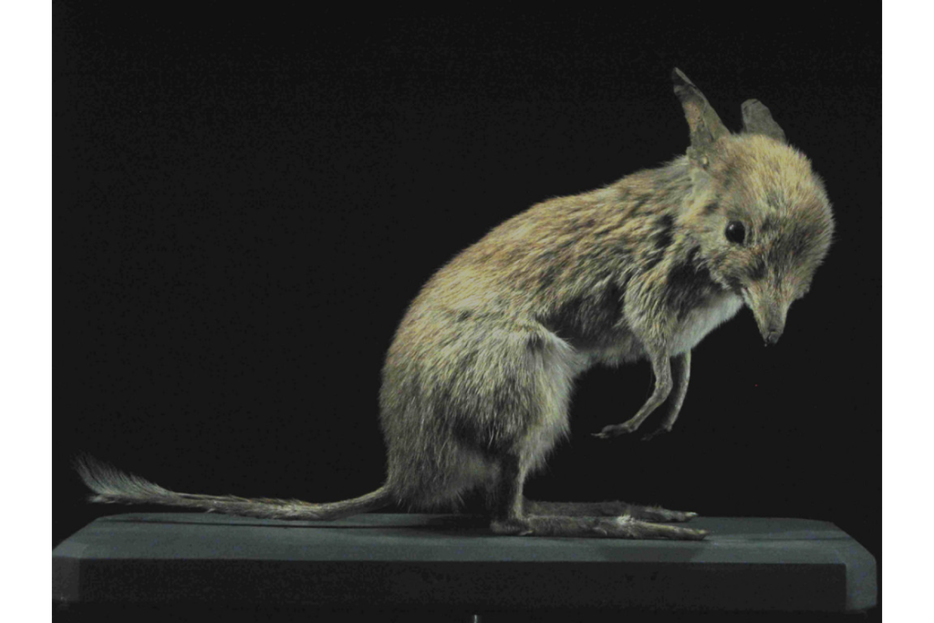

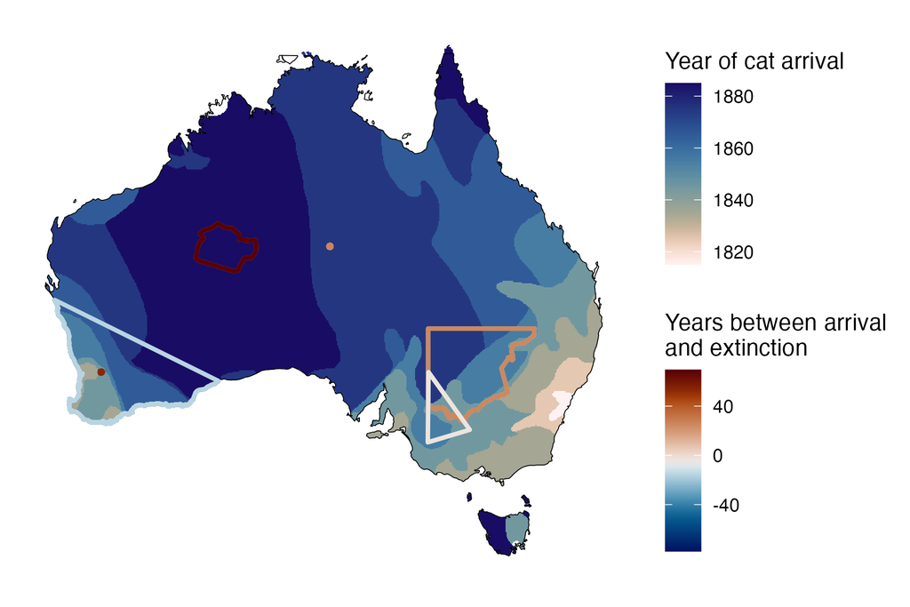

IUCN status: **Extinct**

Last seen: *Chaeropus ecaudatus were last seen in 1901 in Alice Springs, NT (IUCN 2023)*

IUCN claim: *“The extinction of the Pig-footed Bandicoot is attributed to predation by feral cats and red foxes.”*

### Studies in support

Southern pig-footed bandicoots were last confirmed at Alice Springs, the Western Division of NSW, and Youndegin 21-31, 0-50 and 48-58 after cats arrived, respectively (Wallach and Lundgren 2025).

### Studies not in support

Southern pig-footed bandicoots were last confirmed in the Murray-Darling and south-west Australia 24 and 50 years before, to 17 and 19 years after, cats arrived, respectively (Wallach and Lundgren 2025).

### Is the threat claim evidence-based?

In two regions it cannot be verified that extirpation occurred after cat arrival.

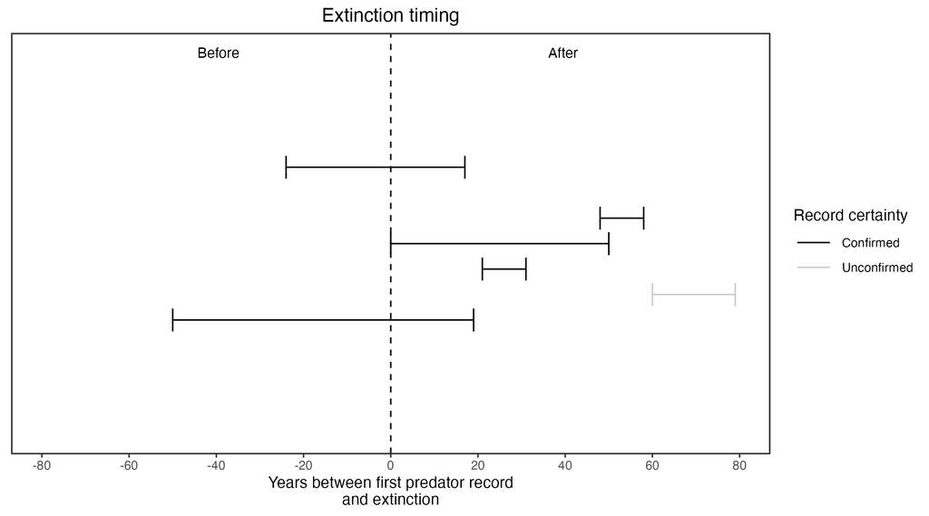

**Evidence linking *Chaeropus ecaudatus* to cats.** Last records of extirpated populations relative to earliest local records of cats. Error bars show record uncertainty range. Predator arrival records were digitized from Abbott 2008.

### References

Abbott, The spread of the cat, Felis catus, in Australia: re-examination of the current conceptual model with additional information. Conservation Science Western Australia 7 (2008).

IUCN Red List. https://www.iucnredlist.org/ Accessed June 2023

Wallach A.D., Lundgren E.J. (2025) Review of evidence that foxes and cats cause extinctions of Australia’s endemic mammals. BioScience. DOI: 10.1093/biosci/biaf046